# Can we Predict Someone’s College Major Category?

Sophia Moore

```r
# Load any R Packages you may need
library(tidyverse)
library(fivethirtyeight)
library(parsnip)
library(baguette)
library(tidymodels)
library(ggridges)
```

```r
#View(college_recent_grads)
```

## Introduction

In my STAT 118 class last semester, I decided to make my final project about various factors that could influence the median salary of a college graduate. In particular, I was interested with how the share of women and salary were correlated (spoiler alert: as the proportion of women increased the salary decreased).

For this project, I am going to use the ‘college_recent_grads’ data from the ‘fivethirtyeight’ package. This set includes various data for college majors, including the proportion of women who got the major, employment status, salary, and more!

Now, with my new knowledge of predictive modeling, I can build a model to see the likely major category of a graduate.

First, I am going to do some exploratory analysis to see which factors influence the ‘major_category’ variable the most.

## Exploratory Analysis

**‘sharewomen’**

Let’s first look at the relationship between the proportion of women in each major and see what the major category is.

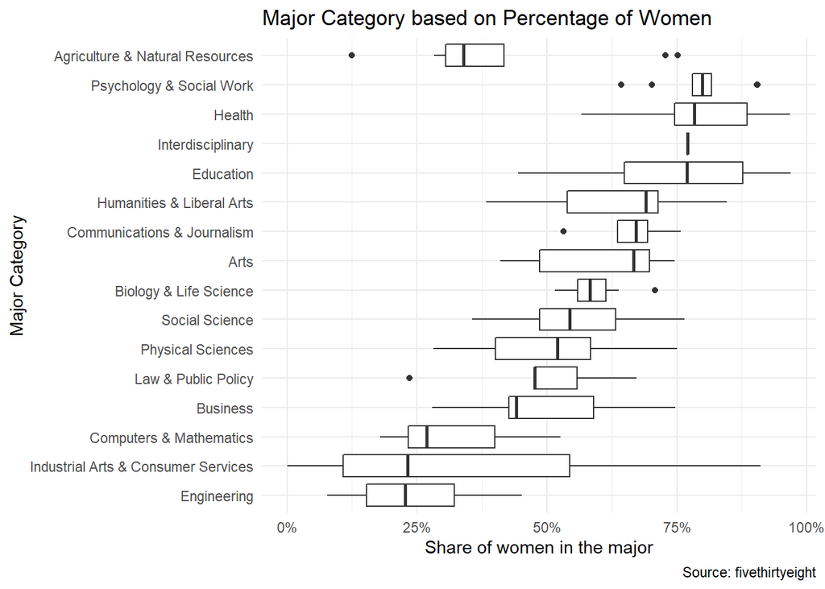

```r
ggplot(college_recent_grads, aes(x = sharewomen, y =fct_reorder(major_category, sharewomen))) +
  geom_boxplot() +
  labs(x = 'Share of women in the major', y = 'Major Category', title = 'Major Category based on Percentage of Women', caption = 'Source: fivethirtyeight') +
  theme_minimal() +
  scale_x_continuous(labels = scales::percent_format())
```

There are large differences in the share of women in each category, so we know that ‘sharewomen’ should be factored into our predictive model!

**‘median’**

There is likely a correlation between major category and the salary, so let’s see how those two variables are related.

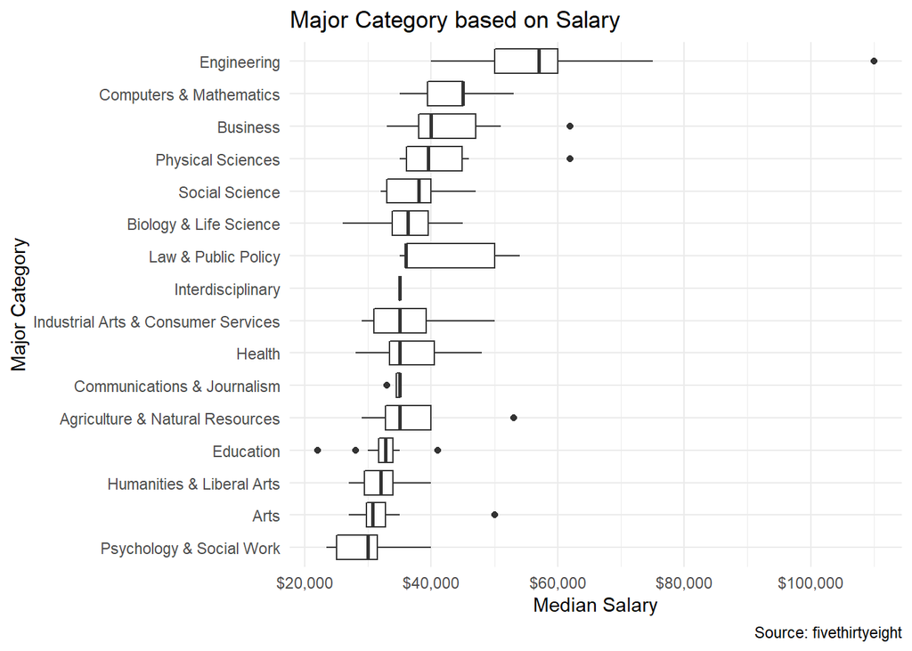

```r
ggplot(college_recent_grads, aes(x = median, y = fct_reorder(major_category, median))) +
  geom_boxplot() +
  labs(x = 'Median Salary', y = 'Major Category', title = 'Major Category based on Salary', caption = 'Source: fivethirtyeight') +
  theme_minimal() +
  scale_x_continuous(labels = scales::dollar_format())
```

Here, we can see that there certainly is a correlation between the major category and the median salary. However, there are some categories that have their salaries overlap (Agriculture and Biology, for example).

Interestingly, the graphs for ‘median’ and ‘sharewomen’ are kind of inverses of each other!

Next, let’s look at the association between major category and the low wage jobs.

**‘low_wage_jobs’**

To look see the relationship between major category and low wage jobs, we first need to change the data a bit to get the low_wage_jobs variable as a percentage instead of a regular number. To do this, let’s divide ‘low_wage_jobs’ by ‘employed’

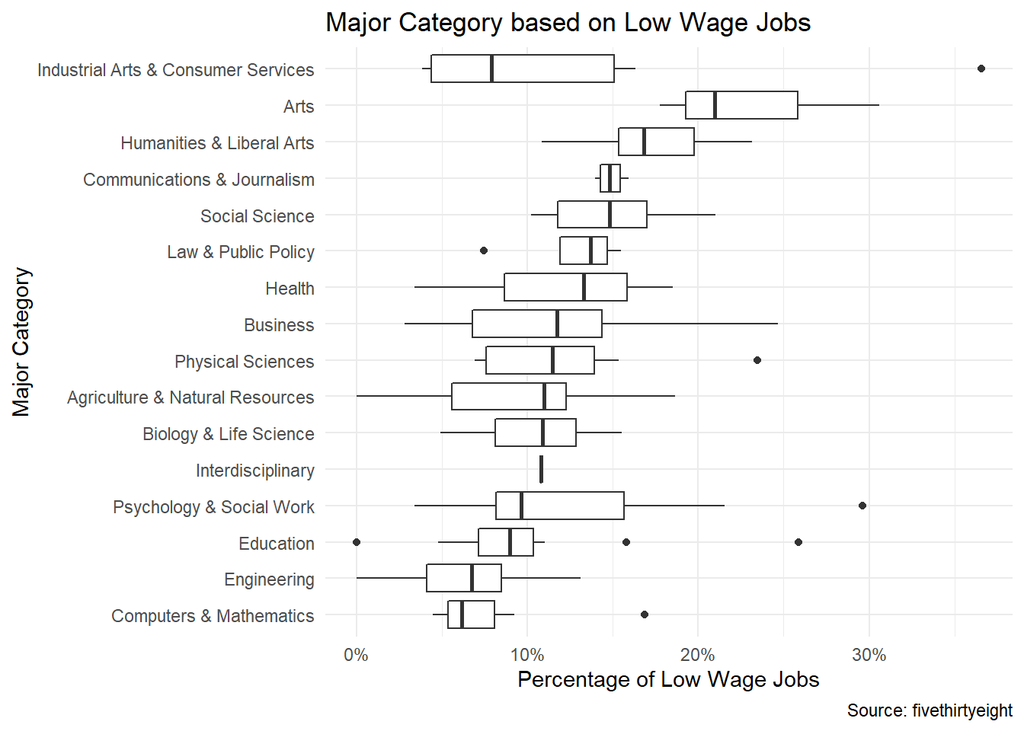

```r
college_recent_grads %>%
  mutate(low_wage_jobs = low_wage_jobs/employed) %>%
  ggplot(aes(x = low_wage_jobs, y = fct_reorder(major_category, low_wage_jobs))) +
  geom_boxplot() +
  labs(x = 'Percentage of Low Wage Jobs', y = 'Major Category', title = 'Major Category based on Low Wage Jobs', caption = 'Source: fivethirtyeight') +
  scale_x_continuous(labels = scales::percent_format())+
  theme_minimal()
```

There is some variation between categories, and it is evident that this variable should be included in the predictive model as well!

## Data Cleaning

```r
college_grads = college_recent_grads %>%
  filter(major_category != c('Interdisciplinary', 'Industrial Arts & Consumer Services'))
```

Additionally, I want to include the variable ‘low_wage_jobs’ and ‘college_jobs’ in my model, but, since it is a straight number, I can’t include it as is.

Therefore, I’m going to make them a fraction of the ‘employed’ variable.

```r
college_grads = college_grads %>%
  mutate(low_wage_jobs = low_wage_jobs/employed, college_jobs = college_jobs/employed)
```

I also want to use ‘employed_fulltime’, so I will convert that to a fraction of the overall ‘employed’ variable.

```r
college_grads = college_grads %>%
  mutate(employed_fulltime = employed_fulltime/employed)
```

We also have to change the ‘major_category’ variable make sure it is a factor. Otherwise, as Professor Scotina likes to put it, “R will yell at us”.

```r
college_grads = college_grads %>%
  mutate(major_category = factor(major_category))
```

## Predictive Modeling

Now that we have an idea of the major factors in the data, we can start constructing our model!!

I would like to see the different predictions when using the following methods:

- decision_tree
- rand_forest
- boost_tree
- bag_tree

To do this, I am going to use a function so I don’t have to redo each of the 4 steps for every method.

```r
predict_major = function(model_type = decision_tree){

#1 Data Splitting
set.seed(228)
college_split = initial_split(college_grads)

college_train = training(college_split)
college_test = testing(college_split)

# Fit Model of user's choice
college_model = model_type() %>%
  set_mode(mode = 'classification') %>%
  fit(major_category ~ median + sharewomen + unemployment_rate + employed_fulltime + college_jobs, data = college_train)

#Generate Predictions
pred_major = college_model %>%
  predict(new_data = college_test)

#Accuracy
college_test %>%
  mutate(major_pred = pred_major$.pred_class) %>%
  accuracy(truth = major_category, estimate = major_pred)
}

#predict_fun(boost_tree)
```

Now that we have the function to make a model, we need to build a loop to iterate through each type of modeling.

- First, we need to make a vector of all the model types we want to include.
- Then, we need to make a list that we will add the accuracy of the models to.
- Finally, as the loop goes through each type in the ‘model_vec’ vector, we add the results of the ‘predict_fun()’ function to the ‘results’ list

```r
model_vec = c('decision_tree', 'rand_forest', 'boost_tree', 'bag_tree')

results1 = list()

for (i in 1:4){
  results1[[i]] = predict_major(get(model_vec[i]))
}

results1
```

```
## [[1]]
## # A tibble: 1 x 3
##   .metric  .estimator .estimate
##   <chr>    <chr>          <dbl>
## 1 accuracy multiclass     0.256
##
## [[2]]
## # A tibble: 1 x 3
##   .metric  .estimator .estimate
##   <chr>    <chr>          <dbl>
## 1 accuracy multiclass     0.395
##
## [[3]]
## # A tibble: 1 x 3
##   .metric  .estimator .estimate
##   <chr>    <chr>          <dbl>
## 1 accuracy multiclass     0.442
##
## [[4]]
## # A tibble: 1 x 3
##   .metric  .estimator .estimate
##   <chr>    <chr>          <dbl>
## 1 accuracy multiclass     0.419
```

```r
accuracy_tab = data.frame(Model = c("Decision Tree", "Random Forest", "Boost Tree", "Bagged Tree"), Accuracy = c(0.256, 0.395, 0.442, 0.419))
accuracy_tab
```

```
##           Model Accuracy
## 1 Decision Tree    0.256
## 2 Random Forest    0.395
## 3    Boost Tree    0.442
## 4   Bagged Tree    0.419
```

Looking at the accuracies, they are relatively low. This could be due to the amount of ‘major_categories’ that is in the data.

**How can we improve the accuracy of the model?**

Instead, let’s see if the accuracies increase when we simply try to predict whether someone is a STEM major or not. To do so, we first need to add a variable of STEM or Not STEM to our data. We can call this variable ‘major_type’, and it will have a value of either ‘STEM’ or ‘Not STEM’. The rows with Biology, Computers and Math, Engineering, and Physical Sciences will all be ‘STEM’, and the rest are ‘Not STEM’.

```r
college_grads = college_grads %>%
  mutate(major_type = ifelse(major_category %in%
                               c("Biology & Life Science", "Computers & Mathematics",
                                 "Engineering", "Physical Sciences"),
                             "STEM", "Not STEM")) %>%
  mutate(major_type = factor(major_type))
```

Now, let’s make a new function that predicts the type of major.

```r
predict_type = function(model_type = decision_tree){

#1 Data Splitting
set.seed(228)
college_split = initial_split(college_grads)

college_train = training(college_split)
college_test = testing(college_split)

# Fit Model of user's choice
college_model = model_type() %>%
  set_mode(mode = 'classification') %>%
  fit(major_type ~ median + sharewomen + unemployment_rate + employed_fulltime + college_jobs, data = college_train)

#Generate Predictions
pred_type = college_model %>%
  predict(new_data = college_test)

#Accuracy
college_test %>%
  mutate(type_pred = pred_type$.pred_class) %>%
  accuracy(truth = major_type, estimate = type_pred)
}
#predict_fun(boost_tree)
```

```r
results2 = list()

for (i in 1:4){
  results2[[i]] = predict_type(get(model_vec[i]))
}

results2
```

```
## [[1]]
## # A tibble: 1 x 3
##   .metric  .estimator .estimate
##   <chr>    <chr>          <dbl>
## 1 accuracy binary         0.814
##
## [[2]]
## # A tibble: 1 x 3
##   .metric  .estimator .estimate
##   <chr>    <chr>          <dbl>
## 1 accuracy binary         0.814
##
## [[3]]
## # A tibble: 1 x 3
##   .metric  .estimator .estimate
##   <chr>    <chr>          <dbl>
## 1 accuracy binary         0.791
##
## [[4]]
## # A tibble: 1 x 3
##   .metric  .estimator .estimate
##   <chr>    <chr>          <dbl>
## 1 accuracy binary         0.814
```

```r
accuracy_tab1 = data.frame(Model = c("Decision Tree", "Random Forest", "Boost Tree", "Bagged Tree"), Accuracy = c(0.814, 0.814, 0.791, 0.814))
accuracy_tab1
```

```
##           Model Accuracy
## 1 Decision Tree    0.814
## 2 Random Forest    0.814
## 3    Boost Tree    0.791
## 4   Bagged Tree    0.814
```

## Conclusion

**predict_major**

Based on our results for the ‘predict_major’ function, the Boost Tree model had the highest accuracy of 44.2%. It is possible that the Boost Tree was able to be the most accurate since it ‘learns’ by fixing errors in the previous trees.

However, none of the models had an incredibly high accuracy (even the best only were able to predict correctly able to predict the outcome 44 or 41% of the time). This could be because the number of different possible outcomes, and there might not have been a lot of difference between the categories in predictive variables. If we look back at the box plot graph that was made in the Exploratory Analysis section, we can see that the median salaries of some of the major categories were in the same range. This could cause confusion in the model.

**predict_type**

Based on the Exploratory Analysis we conducted earlier, the STEM degrees typically had higher salaries as well as a lower percentage of women. This probably made it easier for the models to predict STEM or non-STEM.

A major factor that could also influence the accuracy of the model is the amount of data we have for certain categories. For example, there is a lot of data for Engineering, but there are only 5 majors within the Law and Public Policy category.

One issue that could contribute to a lower accuracy is overfitting. Overfitting normally occurs when the model is fitted too closely to the training dataset. Some powerful modeling methods are prone to this since, and this can cause the predictions for the testing dataset to be incorrect. Overall, it is seen that the models have issues when trying to predict when there are many possible outcomes. Grouping these outcomes together can cause the model to have a higher prediction accuracy!